# Gyroscope Data

###### *Answer:*

Sum missing values

```r
#Number of Missing Values
x <- sum(is.na(activity))
```

Impute the missing values using the `mice` package. Ensure reproducibility by setting seed. We create a `mids` object and then `complete()` it into a data frame.

```r
#Impute missing values
# -convert the activity$date column back to a 'character' class for imputation
# -use mice::complete() to fill dataset using new imputed data
# -#convert the date variable back to a date class (mice needed a character class to impute)
activity$date <- as.character(activity$date)
imputedData <- mice(activity, m=5, maxit=50, meth= 'pmm', seed = 500)
newData <- complete(imputedData,2)
newData$date <- as.Date(newData$date)
```

1. Make a histogram of the total number of steps taken each day and Calculate and report the mean and median total number of steps taken per day. Do these values differ from the estimates from the first part of the assignment? What is the impact of imputing missing data on the estimates of the total daily number of steps?

*Answer:*

##### Data with missing values filled in.

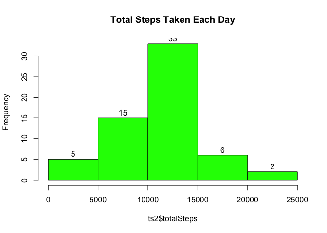

```r
#Get Timeseries data
ts2 <- newData %>%
    select(date,steps)%>%
    group_by(date)%>%
    summarize(avgSteps=mean(steps),
              totalSteps=sum(steps))

#Histogram
hist(ts2$totalSteps, main = "Total Steps Taken Each Day", col = "green", labels = TRUE)
```

```r
#Mean and Median
summary(ts2)
```

```
##       date               avgSteps         totalSteps
##  Min.   :2012-10-01   Min.   : 0.1424   Min.   :   41
##  1st Qu.:2012-10-16   1st Qu.:30.6979   1st Qu.: 8841
##  Median :2012-10-31   Median :37.3785   Median :10765
##  Mean   :2012-10-31   Mean   :37.1062   Mean   :10687
##  3rd Qu.:2012-11-15   3rd Qu.:44.4826   3rd Qu.:12811
##  Max.   :2012-11-30   Max.   :73.5903   Max.   :21194
```

From the above, we can see that the **mean steps per day is 10,687** and the **median steps per day is 10,765**.

*conclusion*: the imputed data impacted the **mean** of our dataset reducing it from 10,766 to 10,687. The **median** remained the same at 10,765.

**Are there differences in activity patterns between weekdays and weekends**

1. For this part the 𝚠𝚎𝚎𝚔𝚍𝚊𝚢𝚜() function may be of some help here. Use the dataset with the filled-in missing values for this part.
2. Create a new factor variable in the dataset with two levels – “weekday” and “weekend” indicating whether a given date is a weekday or weekend day. Make a panel plot containing a time series plot (i.e. 𝚝𝚢𝚙𝚎 = “𝚕”) of the 5-minute interval (x-axis) and the average number of steps taken, averaged across all weekday days or weekend days (y-axis). See the README file in the GitHub repository to see an example of what this plot should look like using simulated data.

*Answer:*

##### Data with missing values filled in.

- The next step is to create a `factor` variable to identify whether or not the date of a record corresponds to a *weekend* or *weekday*. Using `chron` package function `is.weekend()` pass an anonymous function to `sapply` on the `date` column creating new variable `WeekPart` identifying the `date` as corresponding to either a `WEEKEND` or a `WEEKDAY`. This will be used for the plots in later questions.

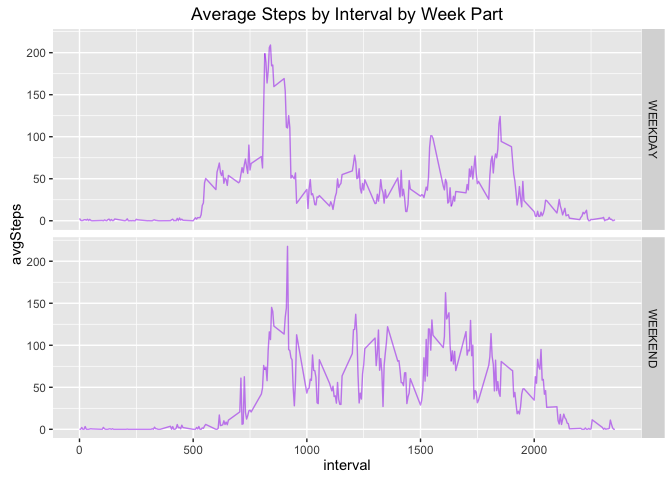

```r
#create a weekday variable for analysis purposes if needed
#create a WeekPart variable by passing an anonymous function to identify
#     if it's a WEEKEND or WEEKDAY using the chron::is.weekend() fx
activity <- newData %>%
    mutate(dayofweek = as.character(weekdays(date))) %>%
    mutate(WeekPart = as.factor(sapply(date,function(x){if(is.weekend(x))
                                           {"WEEKEND"}else{"WEEKDAY"}})))

#Get Timeseries data
d <- activity %>%
    select(date,interval,WeekPart,steps)%>%
    group_by(interval,WeekPart)%>%
    summarize(avgSteps=mean(steps),
              totalSteps=sum(steps))

#plot timeseries

p <- ggplot(d,aes(x=interval,y=avgSteps))+
    geom_line(stat="identity",color="purple",alpha=0.5)+
    ggtitle(label = "Average Steps by Interval by Week Part")+
    facet_grid(WeekPart ~ .)

plot(p)
```